# Data Science: With The Beatles!

[figure not shown]

## Statistically the Best Rock Band / Pop Act Ever?

##### Developed by C. Michael Rodriguez using Python and Jupyter Notebook - Revised April 13th, 2025

##### Copyright © 2024-2025 C. Michael Rodriguez / Argonne Website Design. All Rights Reserved.

## On Thursday, November 2nd, 2023; the legendary rock band The Beatles released their last single ever "Now and Then" and topped the Billboard charts at #1 in the U.K. The world experienced Beatlemania again for the first time in over a half-century.

## Because of that feat, they beat a record previously held by the magnificent Kate Bush, who had enjoyed renewed popularity due to her song "Running Up That Hill"'s resurgence in the Netflix streaming hit "Stranger Things" and it's run to #1 on the U.K. charts in 2022, for the longest period of time between #1 hits for an act (44 years since her hit "Wuthering Heights" in 1978) after their previous hit, "The Ballad of John & Yoko" in 1969, was #1 54 years before in 1969 ... and beat it by 10 years!

## And if that wasn't enough awesomeness, they followed that up in February of 2025 by winning the Grammy Award for Best Rock Performance with it as the first song assisted by Artificial Intelligence technology to win a Grammy in history. Never satisfied with complacency, The Beatles still continued to blaze trails as rock pioneers up until their very last song recorded with all four members; John, Paul, George, & Ringo! AND it was produced by Giles Martin, talented son of their genius A&R man and producer, Sir George Martin (R.I.P.) -- Mind blown.

## How many bands can say they've done all that?!? First of all; NONE. Secondly, especially not with half of the members on the track having passed away by the time it was released!

## Might it be possible to gain some insight on how their success has endured and why many call them the best rock band to have ever existed?

## This notebook details the journey for that answer using data science...

### This analysis will seek to answer the question at hand by following the data science methodology of the "4 M's" with **Key Concepts** in **bold** font throughout the presentation:

### 1) Motivation - What is the question we are trying to answer or business problem we are trying to solve? What is the thesis?

### 2) Method - How exactly are we going to answer or solve it? What processes or practices will be implemented to allow us to come to a resolution? What points are going to support our thesis?

### 3) Mechanics - What tools will be employed as the nuts-and-bolts proof supporting our answer or solution to the business problem? What will illustrate and detail the points supporting our thesis?

### 4) Message - What's the upshot of our investigation? What did we find? What does it all boil down to? What's the conclusion? What's the answer to our question or solution to our business problem?

## High-Level Motivation: Is it possible to gain insight on how The Beatles success has endured for 60+ years and why many call them the best rock band to have ever existed?

## High-Level Method: **Exploratory Data Analysis (EDA)**

### Review and analyze the U.S. Billboard Hot 100 Chart data history archive looking for trends, patterns, and outliers.

## High-level Mechanics: Use Python & Jupyter Notebook to process, analyze, and visualize data.

### Motivation 1: **Data Collecting** - How reliable is our historical U.S. Billboard Hot 100 Chart source data?

### Method 1: Inspect the input data. Make sure the file isn't corrupted or garbage.

### Mechanics 1: Use Python dataframes system to read data into memory to review & analyze. Confirm this is a structured dataset vs. unstructured.

#### Python module: pandas

#### Python function: pandas.read_csv() - reads data stored in CSV file specified into computer memory; print() - have to use print so that all columns show on screen - prints all columns on multiple rows if need be

#### Python method: isnull() - looks for NaN records in specified column in statement prefix

#### Python attribute returned via method call: pandas.head() - shows sample table layout; all columns with first 5 rows

#### Python variables: df - raw U.S. Billboard Hot 100 source data CSV file downloaded from Billboard website

```python
import pandas as pd
df = pd.read_csv('hot-100-current.csv')
#U.S. Billboard Hot 100 chart from November 2023
print(df.head())
```

```
   chart_week  current_week                              title     performer  \
0  2022-01-01             1    All I Want For Christmas Is You  Mariah Carey
1  2022-01-01             2  Rockin' Around The Christmas Tree    Brenda Lee
2  2022-01-01             3                   Jingle Bell Rock   Bobby Helms
3  2022-01-01             4            A Holly Jolly Christmas     Burl Ives
4  2022-01-01             5                         Easy On Me         Adele

   last_week  peak_pos  wks_on_chart
0        1.0         1            50
1        2.0         2            44
2        4.0         3            41
3        5.0         4            25
4        3.0         1            11
```

### Nope, it's not garbage.

```python
%%html
<iframe width="560" height="315" src="https://www.youtube.com/embed/mTVJB--utdc?si=KY4Rj5W1MYjhstSv&autoplay=1;&amp;controls=1" title="YouTube video player" frameborder="0" allow="accelerometer; clipboard-write; encrypted-media; gyroscope; picture-in-picture; web-share" allowfullscreen></iframe>
<h3>Press the YouTube logo at the bottom of the video screen above to pop-out to a different tab and listen to in the background while you keep reading!</h3>
```

[video not shown]

Press the YouTube logo at the bottom of the video screen above to pop-out to a different tab and listen to in the background while you keep reading!

### Message 1: The data is a structured dataset that is organized in a tabular format with clearly defined fields and relationships. Since the data isn't garbage, move on to the next analysis step.

### Motivation 2: **Preparing the Data** - How does the health of the data's table layout look? Are there any concerns about the consistency of the data?

### Method 2: Get the basic dataframe stats info to dig deeper into the data.

### Mechanics 2: Use Python dataframe analysis functions to analyze raw data.

#### Python function: describe() - relates basic statistical information for each numerical column, isnull() - returns records with NaN values in the column specified, print() - outputs (to screen) the string in quotes or number within the parentheses

#### Python variable: df - raw source data - all records

```python
df.describe()
```

|  | current_week | last_week | peak_pos | wks_on_chart |
| --- | --- | --- | --- | --- |
| count | 341500.000000 | 309040.000000 | 341500.000000 | 341500.000000 |
| mean | 50.500000 | 47.288807 | 40.682214 | 9.291154 |
| std | 28.866032 | 28.179708 | 29.332586 | 7.866871 |
| min | 1.000000 | 0.000000 | 1.000000 | 1.000000 |
| 25% | 26.000000 | 23.000000 | 13.000000 | 4.000000 |
| 50% | 51.000000 | 47.000000 | 38.000000 | 7.000000 |
| 75% | 75.000000 | 71.000000 | 65.000000 | 13.000000 |
| max | 100.000000 | 100.000000 | 100.000000 | 91.000000 |

### Eyeball for anomolies in the stats. Any missing data relative to the rest of the dataset? Count row: "last_week" column = 309040 records with legit values - significantly less than other three numerical columns at 341500. Investigate possible issues: any nulls (aka NaNs [Not a Number] in Python) in any records?

```python
# From above, amount of records suspected to have NaNs or nulls in them
341500-309040
```

```
32460
```

### Find the NaNs.

```python
print(df[df['last_week'].isnull()])
# Yes!! that's it! I got 32640 rows
```

```
        chart_week  current_week                   title  \
10700   1958-08-04             1        Poor Little Fool
10701   1958-08-04             2                Patricia
10702   1958-08-04             3           Splish Splash
10703   1958-08-04             4       Hard Headed Woman
10704   1958-08-04             5                    When
...            ...           ...                     ...
341441  2021-11-13            42  Somebody's Watching Me
341460  2021-11-13            61              Demon High
341480  2021-11-13            81              Rap Freaks
341481  2021-11-13            82                  Eat It
341499  2021-11-13           100              Ghost Town

                                 performer  last_week  peak_pos  wks_on_chart
10700                         Ricky Nelson        NaN         1             1
10701        Perez Prado And His Orchestra        NaN         2             1
10702                          Bobby Darin        NaN         3             1
10703   Elvis Presley With The Jordanaires        NaN         4             1
10704                          Kalin Twins        NaN         5             1
...                                    ...        ...       ...           ...
341441                            Rockwell        NaN         2            20
341460                        Lil Uzi Vert        NaN        61             1
341480                          Yung Miami        NaN        81             1
341481                 Megan Thee Stallion        NaN        82             1
341499                        Benson Boone        NaN       100             1

[32460 rows x 7 columns]
```

```python
# let's take a look at one of the suspect NaN records
# along with other records from the same artist
# what's going on here? Are they all NaNs or no?
print(df[df['performer']=='Rockwell'])
```

```
        chart_week  current_week                   title performer  last_week  \
142272  1984-01-28            73  Somebody's Watching Me  Rockwell        NaN
142351  1984-02-04            52  Somebody's Watching Me  Rockwell       73.0
142432  1984-02-11            33  Somebody's Watching Me  Rockwell       52.0
142525  1984-02-18            26  Somebody's Watching Me  Rockwell       33.0
142611  1984-02-25            12  Somebody's Watching Me  Rockwell       26.0
142706  1984-03-03             7  Somebody's Watching Me  Rockwell       12.0
142804  1984-03-10             5  Somebody's Watching Me  Rockwell        7.0
142902  1984-03-17             3  Somebody's Watching Me  Rockwell        5.0
143001  1984-03-24             2  Somebody's Watching Me  Rockwell        3.0
143101  1984-03-31             2  Somebody's Watching Me  Rockwell        2.0
143201  1984-04-07             2  Somebody's Watching Me  Rockwell        2.0
143302  1984-04-14             3  Somebody's Watching Me  Rockwell        2.0
143406  1984-04-21             7  Somebody's Watching Me  Rockwell        3.0
143510  1984-04-28            11  Somebody's Watching Me  Rockwell        7.0
```

[output cut: 56 more lines]

```python
%%html
<iframe width="560" height="315" src="https://www.youtube.com/embed/7YvAYIJSSZY?si=KY4Rj5W1MYjhstSv&autoplay=1;&amp;controls=1" title="YouTube video player" frameborder="0" allow="accelerometer; clipboard-write; encrypted-media; gyroscope; picture-in-picture; web-share" allowfullscreen></iframe>
<h3>Press the YouTube logo at the bottom of the video screen above to pop-out to a different tab and listen to in the background while you keep reading!</h3>
```

[video not shown]

Press the YouTube logo at the bottom of the video screen above to pop-out to a different tab and listen to in the background while you keep reading!

### Now that I focused on alleviating my concern about the count anomoly in the last week column, let's zoom out and take a look at the data from an airborne view and see if there are any concerns when looking at the data in a wider scope.

### Motivation 3: Are there any other concerns we may have by widening our scope to look at a sample of ALL of the data records at "1,000 feet", instead of just fousing on the records with NaNs or just one artists' records?

### Method 3: Return a sample of the entire data source recordset to see if there is anything missed by the head() attribute-method call or describe() function.

### Mechanics 3: Have the Python interpreter return a sample of the entire raw data dataframe by printing the dataframe's variable name

#### Python variable: df - raw source data - all records

#### Python function: print() - outputs (to screen) the string in quotes or number within the parentheses

```python
# Let's take a look at a sample of records for the entire dataset,
# not just NaN records or just one artist
print(df)
```

```
        chart_week  current_week                              title  \
0       2022-01-01             1    All I Want For Christmas Is You
1       2022-01-01             2  Rockin' Around The Christmas Tree
2       2022-01-01             3                   Jingle Bell Rock
3       2022-01-01             4            A Holly Jolly Christmas
4       2022-01-01             5                         Easy On Me
...            ...           ...                                ...
341495  2021-11-13            96                    Lets Go Brandon
341496  2021-11-13            97                Just About Over You
341497  2021-11-13            98                 To Be Loved By You
341498  2021-11-13            99                   Let's Go Brandon
341499  2021-11-13           100                         Ghost Town

                                                performer  last_week  \
0                                            Mariah Carey        1.0
```

[output cut: 25 more lines]

### Well, what do we have here? It appears that the title "Let's Go Brandon" charted with two different acts; 1) Lazo Alexander and 2) Bryson Gray, et al. This means that we'll have to group by not just the title to get the stats we want, but also by the performer as well! Otherwise, the records for both performers on that song would be mixed together and that information would just be noise at that point and not very useful, unless we cared about how a particular title did on the charts -- which we don't at this time. (Unless we cared about how songwriting credits and charting of Lennon & McCartney tunes contributed to their success, which is hard to measure up against other acts because not all performers write their own music.)

### Message 3: This means that we'll have to take care to group not just by title going forward, but also by performer in order to get the correct aggregate stats for the dataset.

### Advanced: Might there have been another way to come to this conclusion given the data we've seen so far? Yes, if we were to have noticed that Jingle Bell Rock is a standard and has probably charted for more than one performer. This type of insight is what is called **"Business Knowledge"** in an office setting - usually gained through hands-on experience with the subject matter and/or academic research and education. Here the business knowledge would exist just from the analyst's familiarity with music and the old "standards" on the radio. Let's test our resulting **hypothesis** for Jingle Bell Rock. In the case of Jingle Bell Rock; the 4M's, code, and results for the hypothesis test would look like the following:

### Sub-motivation 3.a: Message 3 hypothesis test; is there more than one performer who has charted with Jingle Bell Rock?

### Sub-method 3.a: Message 3 hypothesis test; **Data Binning** - break out the different performers that charted with Jingle Bell Rock, if any, and give them visibility to prove or disprove hypothesis

### Sub-mechanics 3.a: Message 3 hypothesis test; group the dataframe by performer & title and count each record's non-NaN values for each data point (column) in the resulting aggregate data

#### Python function: groupyby() - bins or buckets all of the like-text records for each column specified and performs aggregate calculation specified by Python method on numerical columns/data

#### Python parameter: as_index=False - prevents the columns specified in the group by from becoming the index of the resulting recordset, leaving them just as regular columns and instead creates a numerical, sequential index column which allows more straightforward use of Python record attributes like iloc[index_num]

#### Python method: count() - counts number of non-NaN values in each numerical column

#### Python variable: jbr_df - "Jingle Bell Rock" DataFrame - stores only records with Jingle Bell Rock as title

```python
# Let's only take a look at records where Jingle Bell rock is the title
jbr_df = df[df['title']=="Jingle Bell Rock"]

# And group by performer, to break out all of the performers
# and make them easily visible
print(jbr_df.groupby(['performer'], as_index=False).count())
```

```
                     performer  chart_week  current_week  title  last_week  \
0                  Bobby Helms          55            55     55         45
1  Bobby Rydell/Chubby Checker           7             7      7          5

   peak_pos  wks_on_chart
0        55            55
1         7             7
```

### Sub-message 3.a: Message 3 hypothesis test; Well, lookie here! Thanks to our familiarity with music on the radio airwaves (or "Business Knowledge of music hits") our hypothesis has been proven correct! There is indeed more than one performer who charted with Jingle Bell Rock. It looks like Bobby Helms beat the pants off of Bobby Rydell and Chubby Checker's version by being on the chart 55 weeks to 7! Well done, Bobby! (You're so dreamy! * snicker * :) )

```python
%%html
<iframe width="560" height="315" src="https://www.youtube.com/embed/ZnDmmiiFSUU?si=KY4Rj5W1MYjhstSv&autoplay=1;&amp;controls=1" title="YouTube video player" frameborder="0" allow="accelerometer; clipboard-write; encrypted-media; gyroscope; picture-in-picture; web-share" allowfullscreen></iframe>
<h3>Press the YouTube logo at the bottom of the video screen above to pop-out to a different tab and listen to in the background while you keep reading!</h3>
```

[video not shown]

Press the YouTube logo at the bottom of the video screen above to pop-out to a different tab and listen to in the background while you keep reading!

### Motivation 4: At a high-level of understanding, I wonder if there is any correlation between how long a track is on the charts for versus how high it will chart?

### Method 4: **Data Visualization:** Since I only care about this at a high-level of understanding for now, let's create a visualization that details how each track that has ever been released and charted on the Billboard Hot 100 trends when taking a look at how high a track charts against how long it stays on the chart.

### Mechanics 4: **Data Visualization:** Let's create a scatterplot that plots points on a graph that shows how high a track charts against how long it's been on the charts.

#### New Python library: matplotlib - library containing various graphing modules (e.g. pyplot)

#### New Python module: matplotlib.pyplot - basic graphing tools module; matplotlib.seaborn - module containing plot graphing functions & tools (they look cooler than pyplot graphics)

#### Python functions: seaborn.scatterplot(data=[dataframe variable],x='[column name1]',y='[column name 2]') - creates scatterplot visualization with related values from column x on x-axis and column y on y-axis; pyplot.xlabel - text label for x-axis; pyplot.ylabel - text label for y-axis; pandas.groupby(); matplotlib.pyplot.gca().invert_yaxis() - inverts the y-axis (to mimic chart climb!)

#### Python method: .agg({'[col1]':'[agg_function w/o ()]'(e.g. 'max'), '[col2]':[agg_function w/o ()]'(e.g. 'min)}) - used with groupby as suffix (after the () )

#### Python parameter: as_index=False - prevents the columns specified in the group by from becoming the index of the resulting recordset, leaving them just as regular columns and instead creates a numerical, sequential index column which allows more straightforward use of Python record attributes like iloc[index_num]

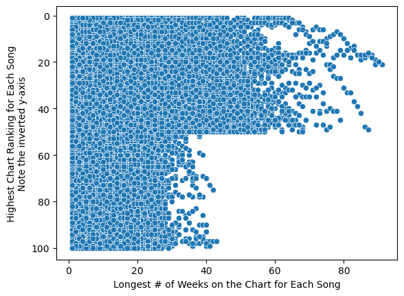

```python
import matplotlib.pyplot as plt
import seaborn as sns
sns.scatterplot(data=df, x="wks_on_chart", y="current_week") #Note the
# Inverted Y-Axis the x & y values above have to be the exact column
# names; they can't be labels
plt.ylabel("Highest Chart Ranking for Each Song\nNote the inverted y-axis")
plt.xlabel("Longest # of Weeks on the Chart for Each Song")
plt.gca().invert_yaxis() # inverts the y-axis to mimic the chart positions!
plt.show;
```

### Motivation 5: Has anyone had a song on the charts longer than the longest Beatles' song ever on the charts?

### Method 5: **Data Binning & Data Aggregation** - First, isolate the Beatles data in their own dataframe and all other artists in a different one to compare easily. I'll also group the ROW (Rest of World) df by performer & title in case there are any songs that were released by more than one artist (a.k.a. covers) and then sort both dfs by wks_on_chart in descending order.

### Two bins/buckets/categories: The Beatles song on the charts the longest vs. the Non-Beatles song on the charts the longest.